# DAIE Pair Project

Descriptive & Inferential Analysis of a Jungian Sandplay VR Project

Joe O’Regan and Michael Galbraith

2022-12-12

### Repo

https://github.com/joeaoregan/2022_DAIE_GCA_JOR_MG

# Abstract

## Aim and Rationale

The purpose of this assignment was to form a hypothesis based on data collected at the beginning and end of a 12 week period of Cognitive Behavioural Therapy (CBT). The data was collected to investigate the effect of Jungian Sandplay therapy in a Virtual Reality environment. Patients were being treated for PTSD. Psychological interventions like this have been shown to have a positive impact.

## Participants and Setting

The study consisted of 150 patients divided equally into 3 groups. An equal representation of male and female patients is present in each group. All patients were young adults aged 18 to 25 with no age information recorded.

- Control (Cognitive Behavioural Therapy patients who did not use the VR app)
- Static (Patients who used a non-animated version of the VR app)
- Animated (Patients who used the animated version of the VR app)

## Experiment Design

Clean the raw data from the CSV file. Split the data into the 3 testing groups: control, static, animated. Split each group into male and female. Use histograms and boxplots to visually inspect outliers.

## Results Gathering

First, cleaning the data to remove errors such as typos and missing values. We used Descriptive Statistics to examine and look at the data. Looking for outliers in the data. Form a hypothesis based on visual inspection of the data in graphs. Then using Inferential Statistics to make predictions and generalizations based on the data. Performing Hypothesis tests to check the validity of the hypothesis based on the data provided.

# Introduction

## Topic and Context

Post‐traumatic stress disorder (PTSD) is seen as one of the most common psychiatric disorder to follow after exposure to a traumatic event. It has been recorded (by ptsd.va.gov) that approx. 6% of the population will have PTSD at some point in time. It has been known that trauma-focused cognitive behaviour therapy is the best-validated threat for PTSD. Although not all PTSD patients respond adequately to this type of treatment. There has also been studies that most people with PTSD do not access evidence-based treatment, and this situation is much worse for lower and middle income countries. This identify that there is still a lot to overcome in the style of treatment to better improve people’s lives with PTSD and remains a challenge.

## Rationale

While CBT is effective in the management of symptoms of PTSD, it doesn’t specifically deal with the underlying cause. Furthermore, not all patients respond to CBT. Therefore, in an effort to improve the outcomes for patients with PTSD we aim to explore the effectiveness of virtual reality assisted cognitive behavioral therapy compared to standard CBT practices.

Kind of simple. We only have a small amount of information, the change in PTSD Levels after 12 weeks, with one possible variable gender that may influence the outcome. Using 3 different treatment methods, with 2 different ratings.

So, we would expect there is either some change, or no change after 12 weeks. Each of the methods may have different outcomes, and the gender of the patients may be a factor in how they respond to each treatment, or to treatment in general by any of the 3 treatments.

## Hypothesis

For a treatment to be a success, the average PTSD levels for both observer rated and self-reported should improve over a 12 week period, across all groups (control, static, animated), and for all patient types (male, female).

H0 (Null hypothesis): There is no difference between the median values of male and female patients measurements over a 12 week period.

H1 (Alternative): There is a difference between the median values of male and female patients measurements over a 12 week period.

# Method

## Participants

The participants involved in the study were all young adults with PTSD in the age range of 18 - 25 years. There were 150 students, equally divided into 75 males and 75 females.

## Design

The patients were allocated into one of three groups;

- Control, static (traditional CBT, no VR)
- Static (non-animated model content, VR)
- Animated (animated model content, VR)

Non-animated means the objects in the virtual environment would be still and not interact. Animated means when you add objects onto the Jungian Sand play they would interact and move around the environment

## Materials

The 3 groups underwent 12 weeks of treatment for 50 minutes per week with a therapist. During that time the patients either underwent traditional CBT; or used one of the two (quality) versions of the VR app.

## Procedure

During the study, PTSD was assessed using observer-rated (i.e., therapist-rated) and self-report (i.e., Child PTSD Symptom Scale Self-Report Version (CPSS-SR)) measurements, respectively. Both measurements are scaled to the range of 0 to 10. Measurements were taken at the start and end of the study.

# Results

## Descriptive Statistics

1. Frequency Distribution
2. Central Tendency
3. Variability

### 1. Frequency Distibution

1.1 Histograms

1.2 Boxplots

### 2. Central Tendancy

2.1 Mean

2.2 Median

2.3 Mode

### 3. Variability

3.1 Standard Deviation

### Raw Data

#### Load Raw Data from CSV File

The raw data is loaded from an external CSV file.

```r
csv_file_name = "../daie_ca3_data_5.csv"
raw_data <- read.csv(csv_file_name)

# names(raw_data) # find name for column1, it's called ...1 elsewhere
```

#### Explore Raw Data

Get column names

```r
names(raw_data)
```

```
## [1] "X"               "gender"          "test_group"      "pre_trial_cpss"
## [5] "post_trial_cpss" "pre_trial_or"    "post_trial_or"
```

Get column data type

```r
sapply(raw_data, typeof)
```

```
##               X          gender      test_group  pre_trial_cpss post_trial_cpss
##       "integer"     "character"     "character"        "double"        "double"
##    pre_trial_or   post_trial_or
##        "double"        "double"
```

#### Raw Data Table

Display the raw data in a paged table.

```r
# show a "prettier" paged table
rmarkdown::paged_table(raw_data)
```

| X | gender | test_group | pre_trial_cpss | post_trial_cpss | pre_trial_or | post_trial_or |
| --- | --- | --- | --- | --- | --- | --- |
| 1 | Male | Static | 6.70 | 6.48 | 7.23 | 6.51 |
| 2 | Male | Static | 5.54 | 6.31 | 5.06 | 6.45 |
| 3 | Male | Static | 6.30 | 4.35 | 6.75 | 4.13 |
| 4 | Male | Static | 5.71 | 5.30 | 5.61 | 5.19 |
| 5 | Male | Static | 4.01 | 4.93 | 3.74 | 5.04 |
| 6 | Male | Static | 6.24 | 4.46 | 6.61 | 4.25 |
| 7 | Male | Static | 5.19 | 4.79 | 5.46 | 4.87 |
| 8 | Male | Static | 5.21 | 6.58 | 4.75 | 6.54 |
| 9 | Male | Static | 6.31 | 5.67 | 6.24 | 5.57 |
| 10 | Male | Static | 6.44 | 5.55 | 6.54 | 5.70 |

[output cut: 140 more lines]

#### Rows with values out of Range (0 to 10)

Check for any values less than 0 or greater than 10. Self-Report and Observer-Rated measurements are scaled to the range 0 to 10.

```r
# identify_rows <- raw_data$pre_trial_cpss < 0 | raw_data$pre_trial_cpss > 10 | raw_data$post_trial_cpss < 0 | raw_data$post_trial_cpss > 10 | raw_data$pre_trial_or < 0 | raw_data$pre_trial_or > 10 | raw_data$post_trial_or < 0 | raw_data$post_trial_or > 10

# function to do same thing as above for 1 column at a time
check_range <- function(value) {
  return(value < 0 | value > 10) # return true if the value is less than 0 or greater than 10, otherwise false
}

identify_rows <- check_range(raw_data$pre_trial_cpss) | check_range(raw_data$post_trial_cpss) | check_range(raw_data$pre_trial_or) | check_range(raw_data$post_trial_or)

data_not_in_range <- raw_data %>%
  select(X, gender, test_group, pre_trial_cpss, post_trial_cpss, pre_trial_or, post_trial_or) %>%
  subset(., identify_rows)

rmarkdown::paged_table(data_not_in_range)
```

| X | gender | test_group | pre_trial_cpss | post_trial_cpss | pre_trial_or | post_trial_or |
| --- | --- | --- | --- | --- | --- | --- |

#### Rows with missing data

Show rows with missing data. We will remove this later.

```r
missing_data <- raw_data %>%
  select(X, gender, test_group, pre_trial_cpss, post_trial_cpss, pre_trial_or, post_trial_or) %>%
  filter(!complete.cases(.))

rmarkdown::paged_table(missing_data)
```

| X | gender | test_group | pre_trial_cpss | post_trial_cpss | pre_trial_or | post_trial_or |
| --- | --- | --- | --- | --- | --- | --- |
| 73 | Male | Control | 6.41 | NA | 6.87 | 5.78 |

#### Values in “gender” should be “Female” and “Male”

Use unique() to find all the different values in the gender column to find/rule out errors

```r
gender_values = unique(raw_data$gender)
gender_values
```

```
## [1] "Male"   "Female" "Feale"
```

#### Values in test_group should be “Control”, “Static”, “Animated”

Use unique() to find all the different values in the test_group column to find/rule out errors

```r
test_group_values = unique(raw_data$test_group)
test_group_values
```

```
## [1] "Static"   "Control"  "Animated" "Anmated"
```

#### Show Rows with Typos

After previously finding the typos “Feale” and “Anmated” with unique(), in gender and test_group columns. Show the rows, so we can be sure they were corrected in the cleaned data later.

```r
typos <- raw_data %>%
  select(X, gender, test_group, pre_trial_cpss, post_trial_cpss, pre_trial_or, post_trial_or) %>%
  filter(gender == "Feale" | test_group == "Anmated")
typos
```

| X | gender | test_group | pre_trial_cpss | post_trial_cpss | pre_trial_or | post_trial_or |
| --- | --- | --- | --- | --- | --- | --- |
| 125 | Male | Anmated | 7.52 | 5.69 | 8.06 | 5.44 |
| 148 | Feale | Animated | 4.21 | 2.86 | 4.58 | 2.62 |

#### Show Rows with Typos or Missing Data

Show all errors. Only Typos and Missing Data have been identified.

```r
typos <- raw_data %>%
  select(X, gender, test_group, pre_trial_cpss, post_trial_cpss, pre_trial_or, post_trial_or) %>%
  filter(gender == "Feale" | test_group == "Anmated" | !complete.cases(.))
typos
```

| X | gender | test_group | pre_trial_cpss | post_trial_cpss | pre_trial_or | post_trial_or |
| --- | --- | --- | --- | --- | --- | --- |
| 73 | Male | Control | 6.41 | NA | 6.87 | 5.78 |
| 125 | Male | Anmated | 7.52 | 5.69 | 8.06 | 5.44 |
| 148 | Feale | Animated | 4.21 | 2.86 | 4.58 | 2.62 |

### Clean Data

The following has been performed to clean the data:

- **Remove rows with missing data:** filter()
  - **Row 73:** removed, as missing value could skew the results, as we don’t know what value should be. Therefore we can’t replace it.
- **Fix typos:** mutate()
  - **Row 125:** “Anmated” becomes “Animated”.
  - **Row 148:** “Feale” becomes “Female”.
- **Check for duplicates:** distinct()
  - No duplicates found

```r
data <- raw_data %>%
  select(X, gender, test_group, pre_trial_cpss, post_trial_cpss, pre_trial_or, post_trial_or) %>%
  distinct() %>% # remove duplicates (none anyway)
  filter(complete.cases(.)) %>% # remove rows with incomplete data
  mutate(gender = recode(gender, "Feale" = "Female")) %>% # change typo in gender column
  mutate(test_group = recode(test_group, "Anmated" = "Animated")) # change typo in test_group column
data
```

| X | gender | test_group | pre_trial_cpss | post_trial_cpss | pre_trial_or | post_trial_or |
| --- | --- | --- | --- | --- | --- | --- |
| 1 | Male | Static | 6.70 | 6.48 | 7.23 | 6.51 |
| 2 | Male | Static | 5.54 | 6.31 | 5.06 | 6.45 |
| 3 | Male | Static | 6.30 | 4.35 | 6.75 | 4.13 |
| 4 | Male | Static | 5.71 | 5.30 | 5.61 | 5.19 |
| 5 | Male | Static | 4.01 | 4.93 | 3.74 | 5.04 |
| 6 | Male | Static | 6.24 | 4.46 | 6.61 | 4.25 |
| 7 | Male | Static | 5.19 | 4.79 | 5.46 | 4.87 |
| 8 | Male | Static | 5.21 | 6.58 | 4.75 | 6.54 |
| 9 | Male | Static | 6.31 | 5.67 | 6.24 | 5.57 |
| 10 | Male | Static | 6.44 | 5.55 | 6.54 | 5.70 |

[output cut: 139 more lines]

### Add Columns for Difference in Pre and Post values

#### Self-Report Measures

```r
data$cpss_diff <- data$pre_trial_cpss - data$post_trial_cpss
```

#### Observer-Rated Measures

```r
data$or_diff <- data$pre_trial_or - data$post_trial_or
```

#### Table with difference columns

```r
data
```

| X | gender | test_group | pre_trial_cpss | post_trial_cpss | pre_trial_or | post_trial_or | cpss_diff | or_diff |
| --- | --- | --- | --- | --- | --- | --- | --- | --- |
| 1 | Male | Static | 6.70 | 6.48 | 7.23 | 6.51 | 0.22 | 0.72 |
| 2 | Male | Static | 5.54 | 6.31 | 5.06 | 6.45 | -0.77 | -1.39 |
| 3 | Male | Static | 6.30 | 4.35 | 6.75 | 4.13 | 1.95 | 2.62 |
| 4 | Male | Static | 5.71 | 5.30 | 5.61 | 5.19 | 0.41 | 0.42 |
| 5 | Male | Static | 4.01 | 4.93 | 3.74 | 5.04 | -0.92 | -1.30 |
| 6 | Male | Static | 6.24 | 4.46 | 6.61 | 4.25 | 1.78 | 2.36 |
| 7 | Male | Static | 5.19 | 4.79 | 5.46 | 4.87 | 0.40 | 0.59 |
| 8 | Male | Static | 5.21 | 6.58 | 4.75 | 6.54 | -1.37 | -1.79 |
| 9 | Male | Static | 6.31 | 5.67 | 6.24 | 5.57 | 0.64 | 0.67 |
| 10 | Male | Static | 6.44 | 5.55 | 6.54 | 5.70 | 0.89 | 0.84 |

[output cut: 139 more lines]

### Split Clean Data into Groups

The 150 patients are divided into 3 groups of 50 in the Raw Data. Each group had an equal number of male and female participants. In the cleaned data 1 record has been removed.

- Control (traditional CBT, no VR)
- Static (non-animated model content, VR)
- Animated (animated model contend, VR)

#### Control Group

The control group has 1 less patient record after cleaning the data

```r
control_group <- filter(data, test_group == "Control")
control_group
```

| X | gender | test_group | pre_trial_cpss | post_trial_cpss | pre_trial_or | post_trial_or | cpss_diff | or_diff |
| --- | --- | --- | --- | --- | --- | --- | --- | --- |
| 51 | Male | Control | 6.99 | 5.40 | 7.25 | 5.55 | 1.59 | 1.70 |
| 52 | Male | Control | 8.01 | 4.32 | 8.38 | 4.49 | 3.69 | 3.89 |
| 53 | Male | Control | 5.32 | 6.00 | 5.13 | 6.13 | -0.68 | -1.00 |
| 54 | Male | Control | 6.46 | 4.69 | 7.01 | 4.50 | 1.77 | 2.51 |
| 55 | Male | Control | 6.11 | 4.89 | 6.07 | 5.04 | 1.22 | 1.03 |
| 56 | Male | Control | 7.10 | 5.67 | 6.75 | 5.80 | 1.43 | 0.95 |
| 57 | Male | Control | 7.62 | 5.63 | 8.14 | 5.42 | 1.99 | 2.72 |
| 58 | Male | Control | 6.75 | 5.02 | 6.75 | 5.24 | 1.73 | 1.51 |
| 59 | Male | Control | 4.98 | 6.22 | 5.38 | 6.12 | -1.24 | -0.74 |
| 60 | Male | Control | 7.56 | 6.69 | 7.81 | 6.71 | 0.87 | 1.10 |

[output cut: 39 more lines]

#### Static Group

```r
static_group <- filter(data, test_group == "Static")
static_group
```

| X | gender | test_group | pre_trial_cpss | post_trial_cpss | pre_trial_or | post_trial_or | cpss_diff | or_diff |
| --- | --- | --- | --- | --- | --- | --- | --- | --- |
| 1 | Male | Static | 6.70 | 6.48 | 7.23 | 6.51 | 0.22 | 0.72 |
| 2 | Male | Static | 5.54 | 6.31 | 5.06 | 6.45 | -0.77 | -1.39 |
| 3 | Male | Static | 6.30 | 4.35 | 6.75 | 4.13 | 1.95 | 2.62 |
| 4 | Male | Static | 5.71 | 5.30 | 5.61 | 5.19 | 0.41 | 0.42 |
| 5 | Male | Static | 4.01 | 4.93 | 3.74 | 5.04 | -0.92 | -1.30 |
| 6 | Male | Static | 6.24 | 4.46 | 6.61 | 4.25 | 1.78 | 2.36 |
| 7 | Male | Static | 5.19 | 4.79 | 5.46 | 4.87 | 0.40 | 0.59 |
| 8 | Male | Static | 5.21 | 6.58 | 4.75 | 6.54 | -1.37 | -1.79 |
| 9 | Male | Static | 6.31 | 5.67 | 6.24 | 5.57 | 0.64 | 0.67 |
| 10 | Male | Static | 6.44 | 5.55 | 6.54 | 5.70 | 0.89 | 0.84 |

[output cut: 40 more lines]

#### Animated Group

```r
animated_group <- filter(data, test_group == "Animated")
animated_group
```

| X | gender | test_group | pre_trial_cpss | post_trial_cpss | pre_trial_or | post_trial_or | cpss_diff | or_diff |
| --- | --- | --- | --- | --- | --- | --- | --- | --- |
| 101 | Male | Animated | 5.25 | 5.21 | 5.79 | 5.31 | 0.04 | 0.48 |
| 102 | Male | Animated | 5.73 | 5.63 | 6.14 | 5.81 | 0.10 | 0.33 |
| 103 | Male | Animated | 4.68 | 4.39 | 4.87 | 4.15 | 0.29 | 0.72 |
| 104 | Male | Animated | 5.12 | 6.54 | 5.52 | 6.43 | -1.42 | -0.91 |
| 105 | Male | Animated | 6.75 | 4.78 | 7.10 | 4.83 | 1.97 | 2.27 |
| 106 | Male | Animated | 7.11 | 5.22 | 7.04 | 5.42 | 1.89 | 1.62 |
| 107 | Male | Animated | 5.59 | 5.23 | 5.52 | 5.21 | 0.36 | 0.31 |
| 108 | Male | Animated | 6.67 | 4.10 | 6.14 | 4.27 | 2.57 | 1.87 |
| 109 | Male | Animated | 5.82 | 5.71 | 5.66 | 5.47 | 0.11 | 0.19 |
| 110 | Male | Animated | 8.02 | 4.86 | 8.36 | 5.04 | 3.16 | 3.32 |

[output cut: 40 more lines]

### 1. Frequency Distribution

#### 1.1 Histograms

Histograms for each group.

#### Control

##### Histogram of Control Group Self-Report (CPPS) Treatment Difference between Start and End

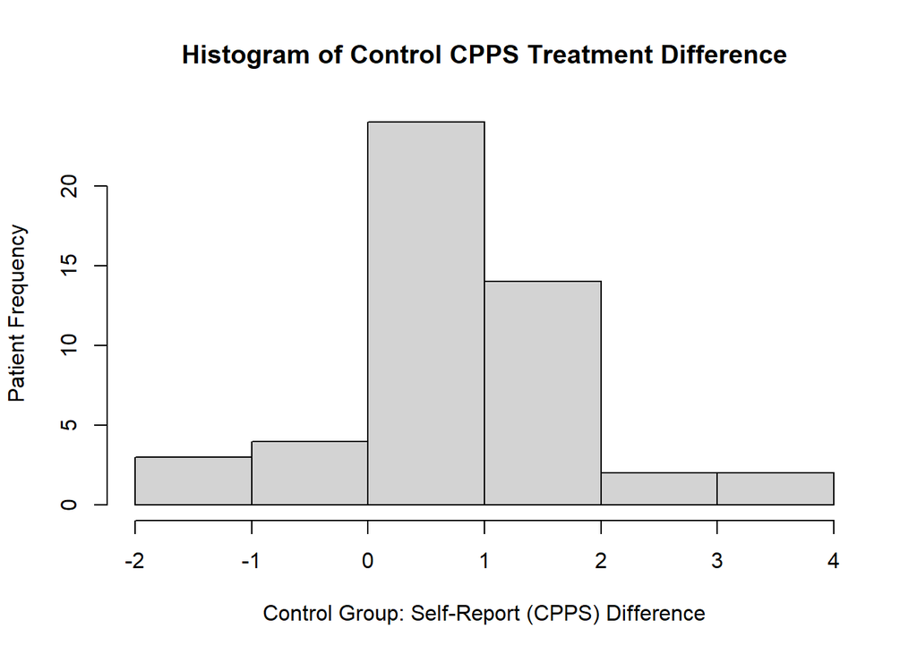

```r
mean_control_cpss <- mean(control_group$cpss_diff)
sd_control_cpss <- sd(control_group$cpss_diff)

# right skewed
hist(control_group$cpss_diff,
     main="Histogram of Control CPPS Treatment Difference",
     xlab="Control Group: Self-Report (CPPS) Difference",
     ylab="Patient Frequency")
```

```r
# hist(rnorm(control_group, mean_control_cpss, sd_control_cpss))  # normal distibution (random sample values generated)
```

##### Histogram of Control Group Observer-Rated (OR) Treatment Difference between Start and End

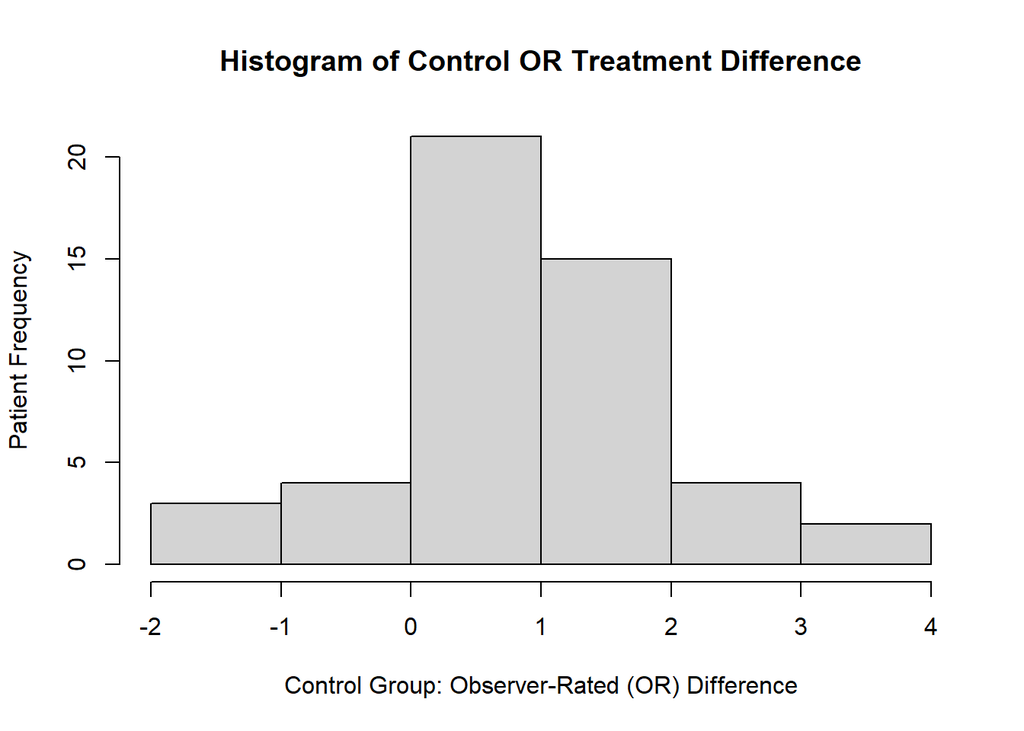

```r
mean_control_or <- mean(control_group$or_diff)
sd_control_or <- sd(control_group$or_diff)

# symmetric? / right?
hist(control_group$or_diff,
     main="Histogram of Control OR Treatment Difference",
     xlab="Control Group: Observer-Rated (OR) Difference",
     ylab="Patient Frequency")
```

```r
# hist(rnorm(control_group, mean_control_or, sd_control_or))
```

#### Static

##### Histogram of Static Group Self-Report (CPPS) Treatment Difference between Start and End

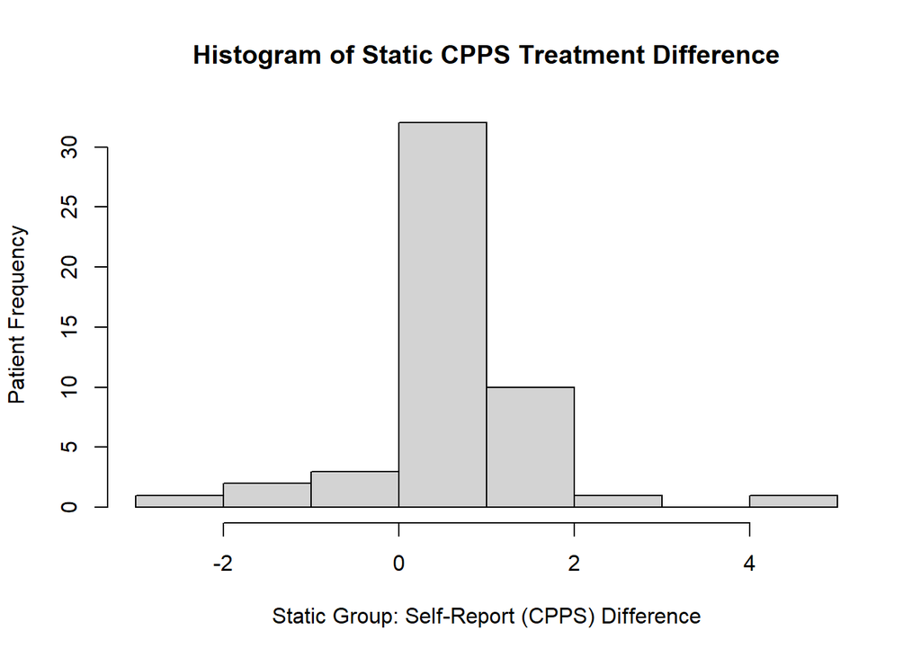

```r
# left skewed (outliers on right)
hist(static_group$cpss_diff,
     main="Histogram of Static CPPS Treatment Difference",
     xlab="Static Group: Self-Report (CPPS) Difference",
     ylab="Patient Frequency")
```

##### Histogram of Static Group Observer-Rated (OR) Treatment Difference between Start and End

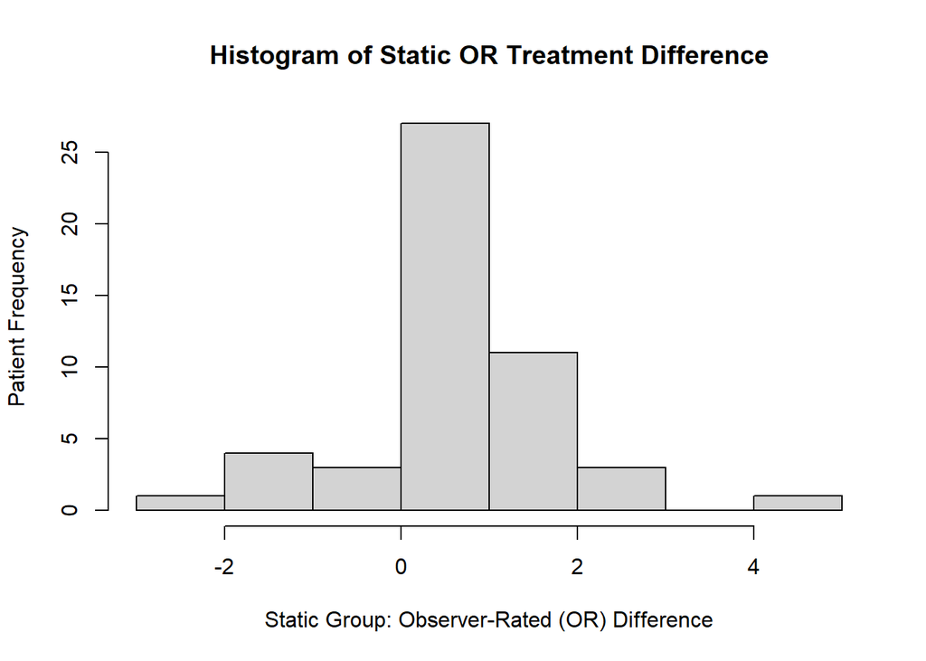

```r
hist(static_group$or_diff,
     main="Histogram of Static OR Treatment Difference",
     xlab="Static Group: Observer-Rated (OR) Difference",
     ylab="Patient Frequency")
```

#### Animated

##### Histogram of Animated Group Self-Report (CPPS) Treatment Difference between Start and End

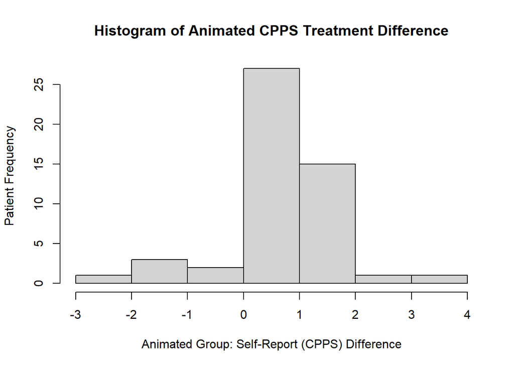

```r
# left skewed
hist(animated_group$cpss_diff,
     main="Histogram of Animated CPPS Treatment Difference",
     xlab="Animated Group: Self-Report (CPPS) Difference",
     ylab="Patient Frequency")
```

##### Histogram of Animated Group Observer-Rated (OR) Treatment Difference between Start and End

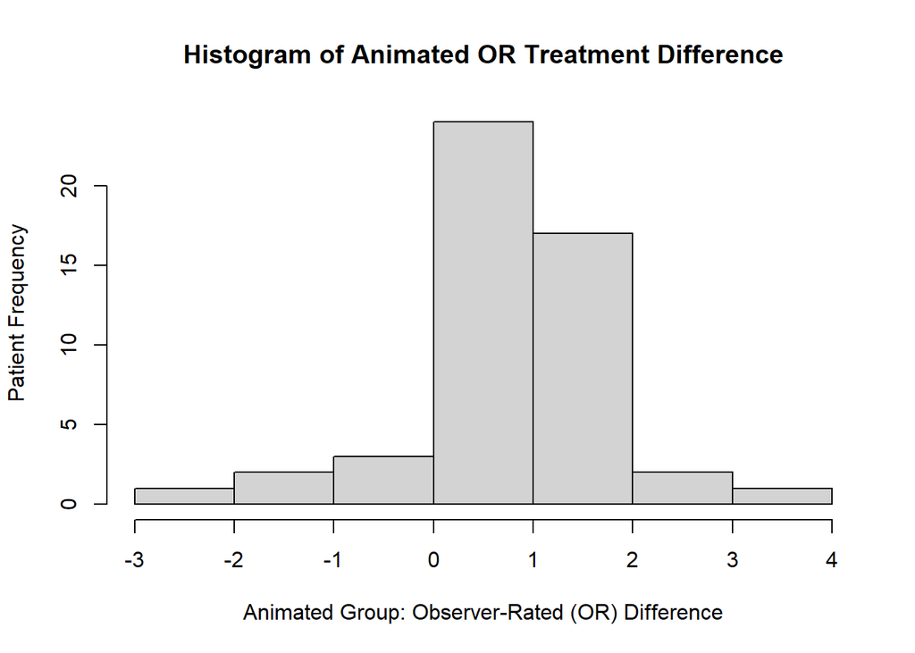

```r
# left skewed
hist(animated_group$or_diff,
     main="Histogram of Animated OR Treatment Difference",
     xlab="Animated Group: Observer-Rated (OR) Difference",
     ylab="Patient Frequency")
```

#### 1.2 Boxplots

Boxplots of each groups treatment difference between Start and End.

Outside the boxplot whiskers, outliers are visible for all groups and for both measurement methods.

#### Control Group

For the control group, outliers are visible for the whole group for both Self-Report and Observer-Rated measurements. When data is divided into Male and Female, outliers are visible only for Female Observer-Rated.

##### Self-Report (CPPS)

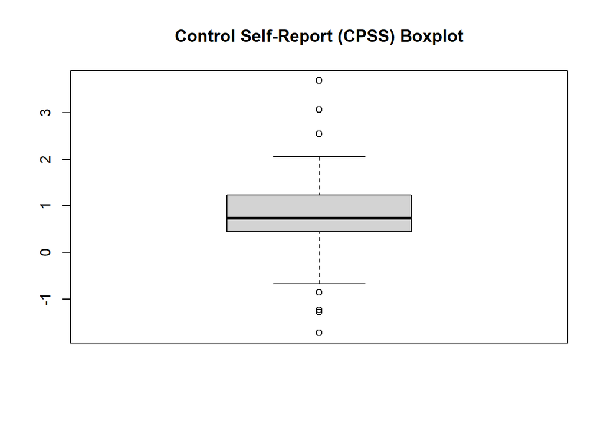

```r
boxplot(control_group$cpss_diff,
        main="Control Self-Report (CPSS) Boxplot")
```

##### Observer-Rated (OR)

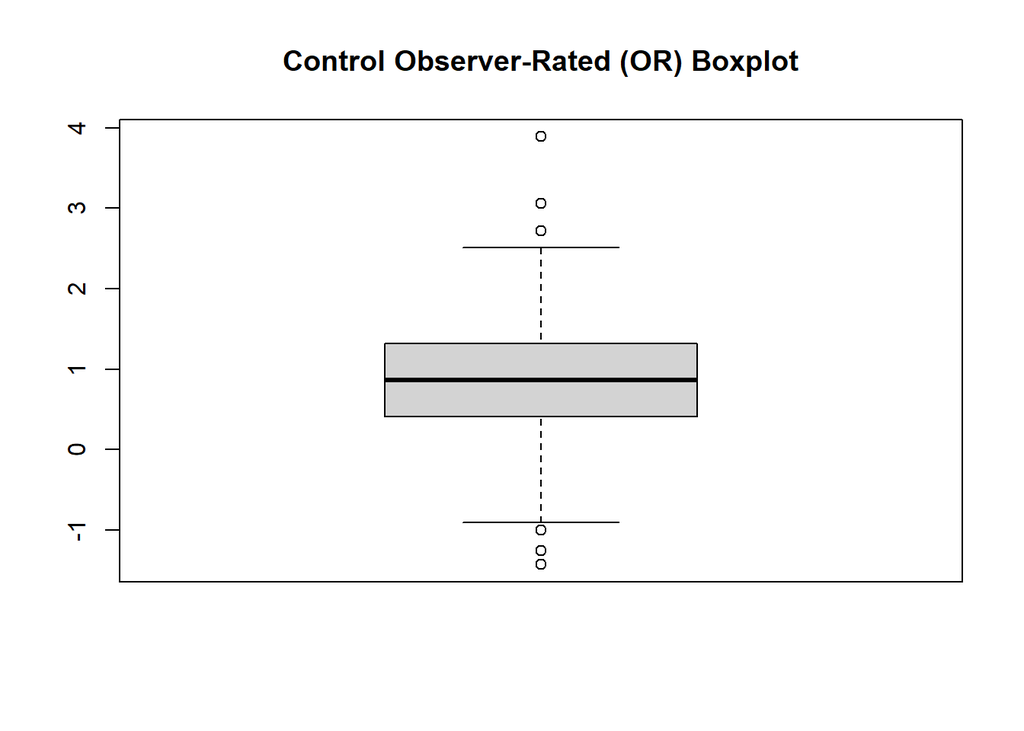

```r
boxplot(control_group$or_diff,
        main="Control Observer-Rated (OR) Boxplot")
```

##### Control - Male

```r
control_male <- filter(control_group, gender == "Male")
control_male
```

| X | gender | test_group | pre_trial_cpss | post_trial_cpss | pre_trial_or | post_trial_or | cpss_diff | or_diff |
| --- | --- | --- | --- | --- | --- | --- | --- | --- |
| 51 | Male | Control | 6.99 | 5.40 | 7.25 | 5.55 | 1.59 | 1.70 |
| 52 | Male | Control | 8.01 | 4.32 | 8.38 | 4.49 | 3.69 | 3.89 |
| 53 | Male | Control | 5.32 | 6.00 | 5.13 | 6.13 | -0.68 | -1.00 |
| 54 | Male | Control | 6.46 | 4.69 | 7.01 | 4.50 | 1.77 | 2.51 |
| 55 | Male | Control | 6.11 | 4.89 | 6.07 | 5.04 | 1.22 | 1.03 |
| 56 | Male | Control | 7.10 | 5.67 | 6.75 | 5.80 | 1.43 | 0.95 |
| 57 | Male | Control | 7.62 | 5.63 | 8.14 | 5.42 | 1.99 | 2.72 |
| 58 | Male | Control | 6.75 | 5.02 | 6.75 | 5.24 | 1.73 | 1.51 |
| 59 | Male | Control | 4.98 | 6.22 | 5.38 | 6.12 | -1.24 | -0.74 |
| 60 | Male | Control | 7.56 | 6.69 | 7.81 | 6.71 | 0.87 | 1.10 |

[output cut: 14 more lines]

###### Control Male - Self-Report (CPPS)

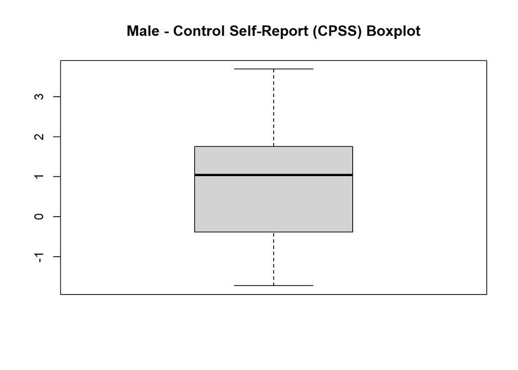

```r
boxplot(control_male$cpss_diff,
        main="Male - Control Self-Report (CPSS) Boxplot")
```

###### Control Male - Observer-Rated (OR)

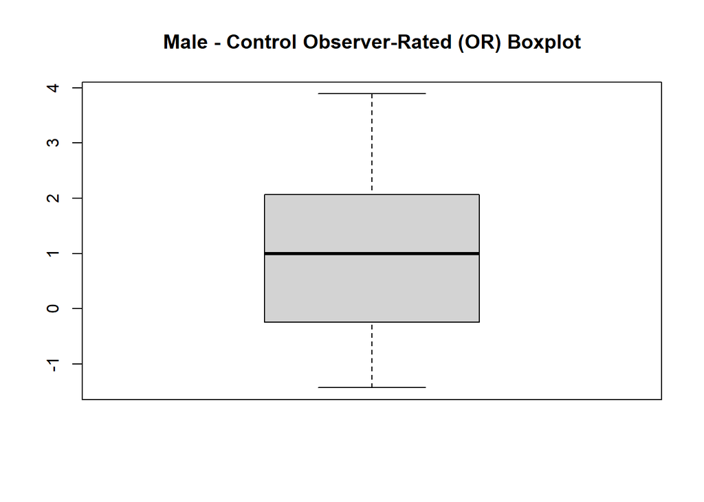

```r
boxplot(control_male$or_diff,
        main="Male - Control Observer-Rated (OR) Boxplot")
```

##### Control - Female

```r
control_female <- filter(control_group, gender == "Female")
control_female
```

| X | gender | test_group | pre_trial_cpss | post_trial_cpss | pre_trial_or | post_trial_or | cpss_diff | or_diff |
| --- | --- | --- | --- | --- | --- | --- | --- | --- |
| 76 | Female | Control | 6.00 | 5.34 | 6.47 | 5.32 | 0.66 | 1.15 |
| 77 | Female | Control | 6.16 | 5.56 | 6.48 | 5.62 | 0.60 | 0.86 |
| 78 | Female | Control | 4.51 | 3.28 | 5.04 | 3.44 | 1.23 | 1.60 |
| 79 | Female | Control | 6.11 | 5.49 | 5.65 | 5.24 | 0.62 | 0.41 |
| 80 | Female | Control | 5.11 | 4.11 | 4.90 | 4.25 | 1.00 | 0.65 |
| 81 | Female | Control | 7.70 | 7.69 | 7.98 | 7.64 | 0.01 | 0.34 |
| 82 | Female | Control | 6.24 | 5.67 | 6.48 | 5.61 | 0.57 | 0.87 |
| 83 | Female | Control | 5.80 | 5.06 | 5.91 | 5.25 | 0.74 | 0.66 |
| 84 | Female | Control | 4.24 | 2.90 | 4.03 | 2.71 | 1.34 | 1.32 |
| 85 | Female | Control | 5.86 | 5.14 | 5.87 | 5.09 | 0.72 | 0.78 |

[output cut: 15 more lines]

###### Control Female - Self-Report (CPPS)

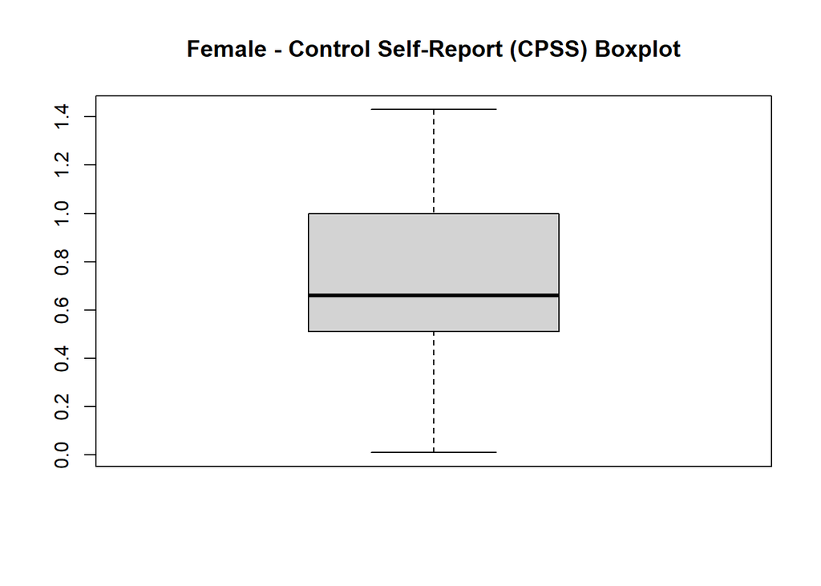

```r
boxplot(control_female$cpss_diff,
        main="Female - Control Self-Report (CPSS) Boxplot")
```

###### Control Female - Observer-Rated (OR)

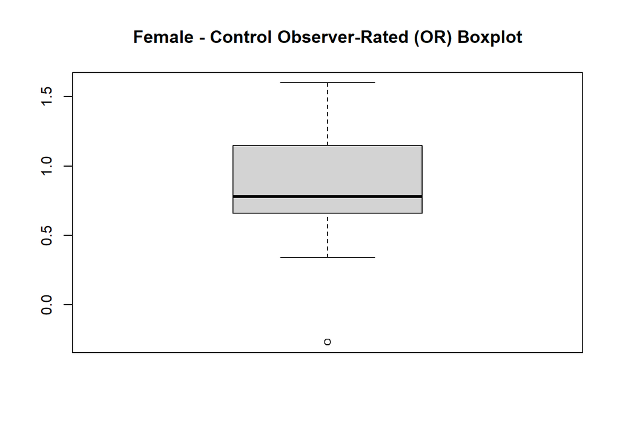

```r
boxplot(control_female$or_diff,
        main="Female - Control Observer-Rated (OR) Boxplot")
```

#### Static Group

For the static group, outliers are visible for the whole group for both Self-Report and Observer-Rated measurements. When data is divided into Male and Female, outliers are visible only for male measurements, and in both Self-Report and Observer-Rated measurements.

##### Self-Report (CPPS)

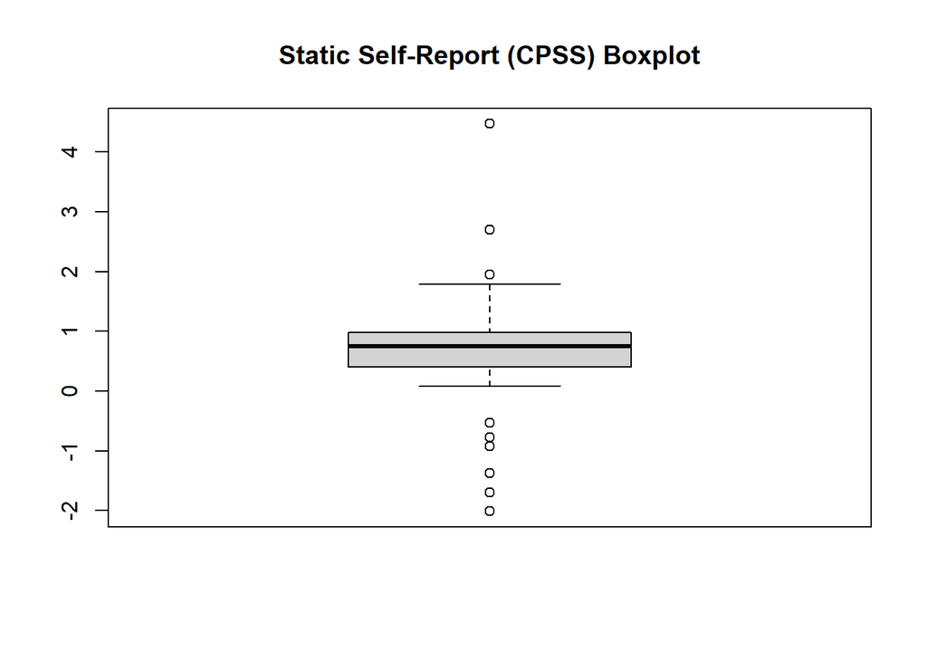

```r
boxplot(static_group$cpss_diff,
        main="Static Self-Report (CPSS) Boxplot")
```

##### Observer-Rated (OR)

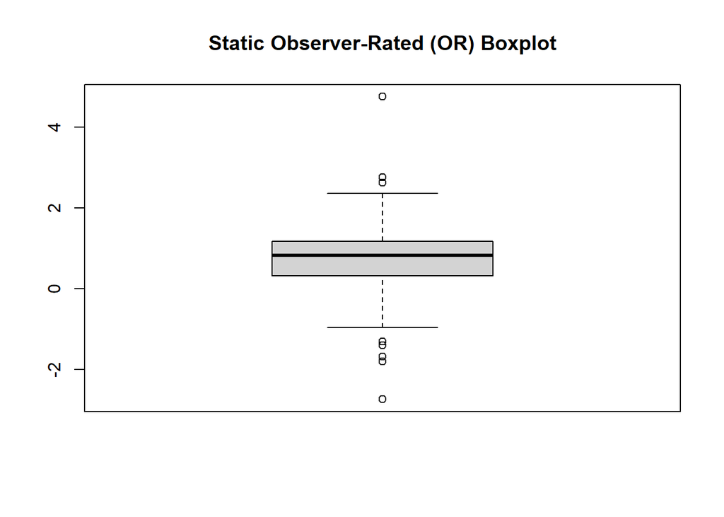

```r
boxplot(static_group$or_diff,
        main="Static Observer-Rated (OR) Boxplot")
```

##### Static Group Male

Outliers are visible for both male measurement methods.

```r
static_male <- filter(static_group, gender == "Male")
static_male
```

| X | gender | test_group | pre_trial_cpss | post_trial_cpss | pre_trial_or | post_trial_or | cpss_diff | or_diff |
| --- | --- | --- | --- | --- | --- | --- | --- | --- |
| 1 | Male | Static | 6.70 | 6.48 | 7.23 | 6.51 | 0.22 | 0.72 |
| 2 | Male | Static | 5.54 | 6.31 | 5.06 | 6.45 | -0.77 | -1.39 |
| 3 | Male | Static | 6.30 | 4.35 | 6.75 | 4.13 | 1.95 | 2.62 |
| 4 | Male | Static | 5.71 | 5.30 | 5.61 | 5.19 | 0.41 | 0.42 |
| 5 | Male | Static | 4.01 | 4.93 | 3.74 | 5.04 | -0.92 | -1.30 |
| 6 | Male | Static | 6.24 | 4.46 | 6.61 | 4.25 | 1.78 | 2.36 |
| 7 | Male | Static | 5.19 | 4.79 | 5.46 | 4.87 | 0.40 | 0.59 |
| 8 | Male | Static | 5.21 | 6.58 | 4.75 | 6.54 | -1.37 | -1.79 |
| 9 | Male | Static | 6.31 | 5.67 | 6.24 | 5.57 | 0.64 | 0.67 |
| 10 | Male | Static | 6.44 | 5.55 | 6.54 | 5.70 | 0.89 | 0.84 |

[output cut: 15 more lines]

###### Static Male - Self-Report (CPPS)

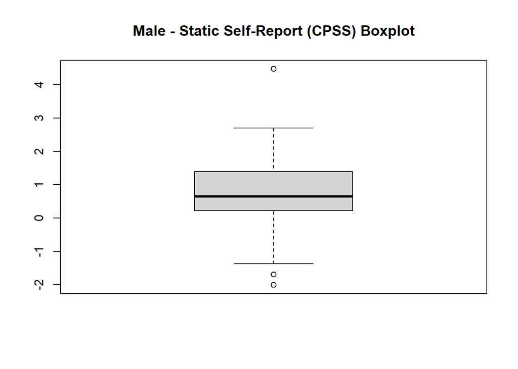

```r
boxplot(static_male$cpss_diff,
        main="Male - Static Self-Report (CPSS) Boxplot")
```

###### Static Male - Observer-Rated (OR)

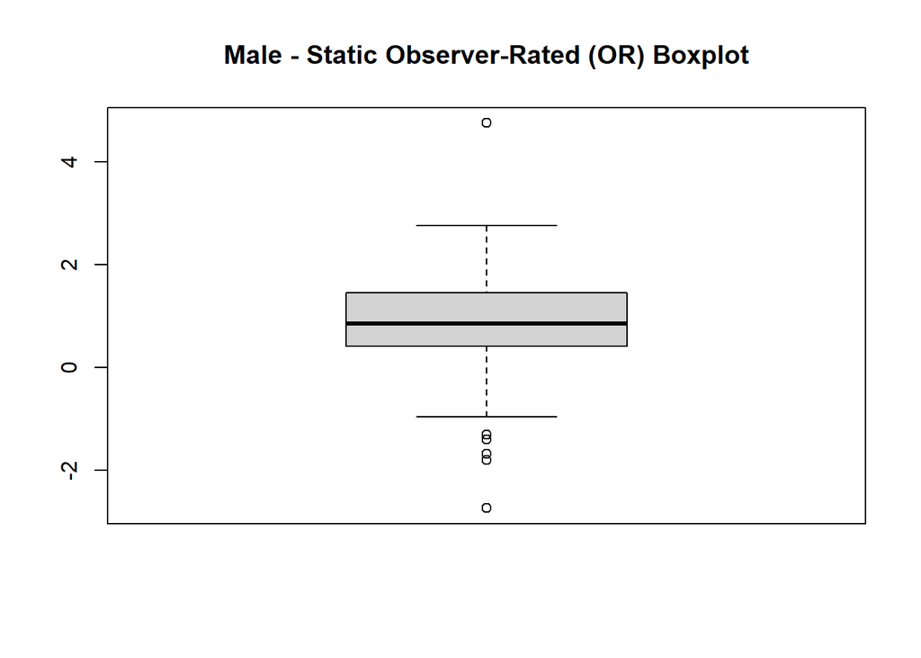

```r
boxplot(static_male$or_diff,
        main="Male - Static Observer-Rated (OR) Boxplot")
```

##### Static Group Female

No outliers are visible for female measurement methods.

```r
static_female <- filter(static_group, gender == "Female")
static_female
```

| X | gender | test_group | pre_trial_cpss | post_trial_cpss | pre_trial_or | post_trial_or | cpss_diff | or_diff |
| --- | --- | --- | --- | --- | --- | --- | --- | --- |
| 26 | Female | Static | 5.60 | 4.79 | 5.62 | 4.69 | 0.81 | 0.93 |
| 27 | Female | Static | 7.29 | 7.13 | 6.95 | 6.95 | 0.16 | 0.00 |
| 28 | Female | Static | 5.52 | 4.67 | 5.48 | 4.47 | 0.85 | 1.01 |
| 29 | Female | Static | 5.64 | 4.84 | 5.29 | 4.99 | 0.80 | 0.30 |
| 30 | Female | Static | 7.47 | 7.38 | 7.45 | 7.14 | 0.09 | 0.31 |
| 31 | Female | Static | 6.19 | 5.60 | 6.59 | 5.59 | 0.59 | 1.00 |
| 32 | Female | Static | 5.09 | 4.08 | 5.55 | 4.17 | 1.01 | 1.38 |
| 33 | Female | Static | 6.29 | 5.74 | 6.27 | 5.53 | 0.55 | 0.74 |
| 34 | Female | Static | 4.71 | 3.55 | 4.20 | 3.65 | 1.16 | 0.55 |
| 35 | Female | Static | 7.10 | 6.86 | 7.43 | 6.72 | 0.24 | 0.71 |

[output cut: 15 more lines]

###### Static Female - Self-Report (CPPS)

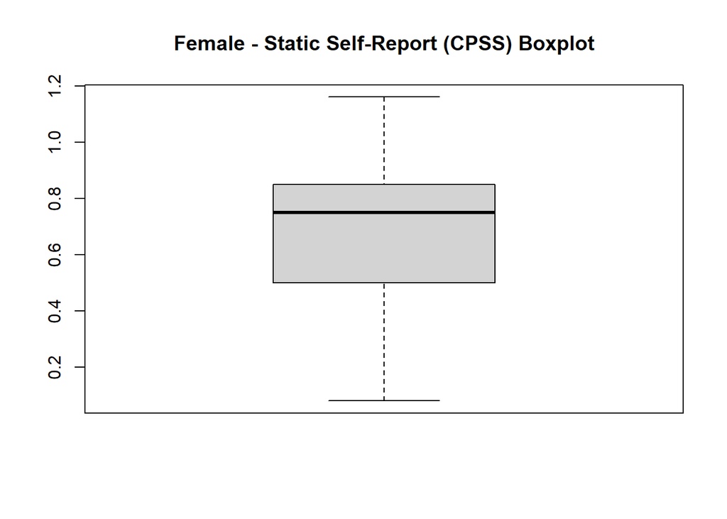

```r
boxplot(static_female$cpss_diff,
        main="Female - Static Self-Report (CPSS) Boxplot")
```

###### Static Female - Observer-Rated (OR)

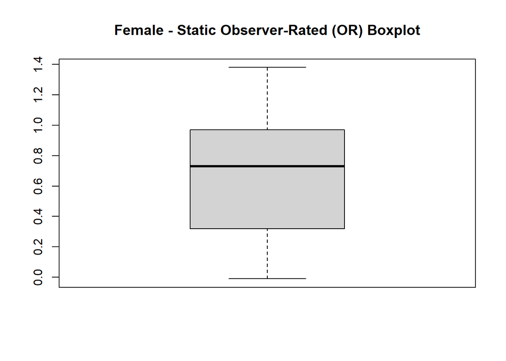

```r
boxplot(static_female$or_diff,
        main="Female - Static Observer-Rated (OR) Boxplot")
```

#### Animated Group

For the animated group, outliers are visible for the whole group for both Self-Report and Observer-Rated measurements. When data is divided into Male and Female, outliers are visible for male Observer-Rated measurements only.

##### Self-Report (CPPS)

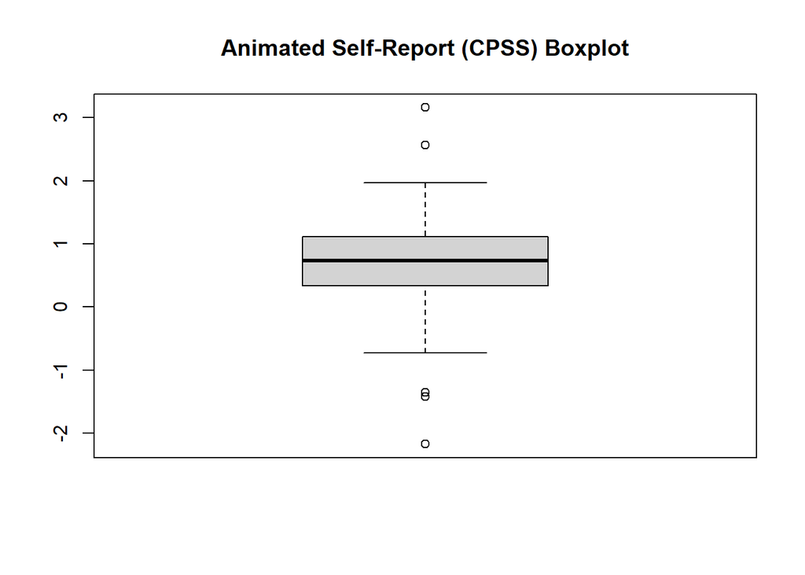

```r
boxplot(animated_group$cpss_diff,
        main="Animated Self-Report (CPSS) Boxplot")
```

##### Observer-Rated (OR)

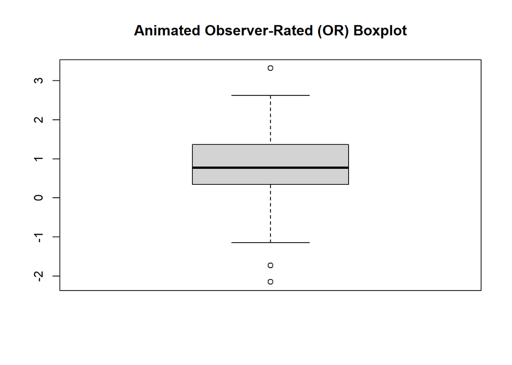

```r
boxplot(animated_group$or_diff,
        main="Animated Observer-Rated (OR) Boxplot")
```

##### Animated Group Male

```r
animated_male <- filter(animated_group, gender == "Male")
animated_male
```

| X | gender | test_group | pre_trial_cpss | post_trial_cpss | pre_trial_or | post_trial_or | cpss_diff | or_diff |
| --- | --- | --- | --- | --- | --- | --- | --- | --- |
| 101 | Male | Animated | 5.25 | 5.21 | 5.79 | 5.31 | 0.04 | 0.48 |
| 102 | Male | Animated | 5.73 | 5.63 | 6.14 | 5.81 | 0.10 | 0.33 |
| 103 | Male | Animated | 4.68 | 4.39 | 4.87 | 4.15 | 0.29 | 0.72 |
| 104 | Male | Animated | 5.12 | 6.54 | 5.52 | 6.43 | -1.42 | -0.91 |
| 105 | Male | Animated | 6.75 | 4.78 | 7.10 | 4.83 | 1.97 | 2.27 |
| 106 | Male | Animated | 7.11 | 5.22 | 7.04 | 5.42 | 1.89 | 1.62 |
| 107 | Male | Animated | 5.59 | 5.23 | 5.52 | 5.21 | 0.36 | 0.31 |
| 108 | Male | Animated | 6.67 | 4.10 | 6.14 | 4.27 | 2.57 | 1.87 |
| 109 | Male | Animated | 5.82 | 5.71 | 5.66 | 5.47 | 0.11 | 0.19 |
| 110 | Male | Animated | 8.02 | 4.86 | 8.36 | 5.04 | 3.16 | 3.32 |

[output cut: 15 more lines]

###### Animated Male - Self-Report (CPPS)

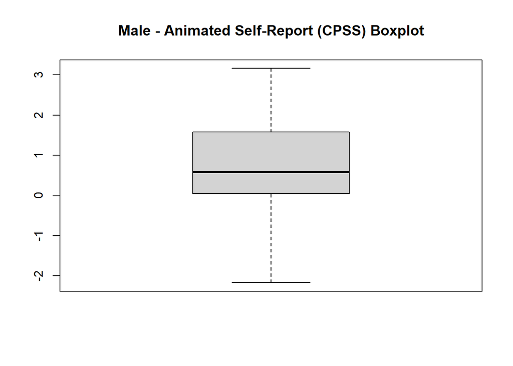

```r
boxplot(animated_male$cpss_diff,
        main="Male - Animated Self-Report (CPSS) Boxplot")
```

###### Animated Male - Observer-Rated (OR)

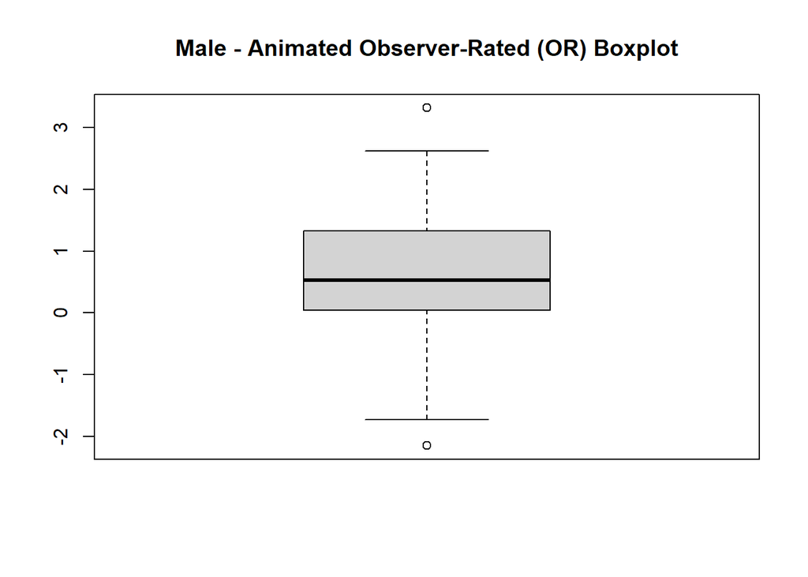

```r
boxplot(animated_male$or_diff,
        main="Male - Animated Observer-Rated (OR) Boxplot")
```

##### Animated Group Female

No outliers are visible for female measurement methods.

```r
animated_female <- filter(animated_group, gender == "Female")
animated_female
```

| X | gender | test_group | pre_trial_cpss | post_trial_cpss | pre_trial_or | post_trial_or | cpss_diff | or_diff |
| --- | --- | --- | --- | --- | --- | --- | --- | --- |
| 126 | Female | Animated | 5.36 | 4.45 | 5.74 | 4.37 | 0.91 | 1.37 |
| 127 | Female | Animated | 6.34 | 5.80 | 5.80 | 5.67 | 0.54 | 0.13 |
| 128 | Female | Animated | 4.85 | 3.74 | 4.68 | 3.69 | 1.11 | 0.99 |
| 129 | Female | Animated | 5.44 | 4.56 | 5.08 | 4.61 | 0.88 | 0.47 |
| 130 | Female | Animated | 6.34 | 5.81 | 6.52 | 5.79 | 0.53 | 0.73 |
| 131 | Female | Animated | 3.65 | 2.08 | 3.35 | 1.90 | 1.57 | 1.45 |
| 132 | Female | Animated | 5.27 | 4.32 | 5.72 | 4.08 | 0.95 | 1.64 |
| 133 | Female | Animated | 6.56 | 6.12 | 6.28 | 6.04 | 0.44 | 0.24 |
| 134 | Female | Animated | 5.10 | 4.08 | 5.67 | 4.09 | 1.02 | 1.58 |
| 135 | Female | Animated | 6.17 | 5.57 | 6.46 | 5.77 | 0.60 | 0.69 |

[output cut: 15 more lines]

###### Animated Female - Self-Report (CPPS)

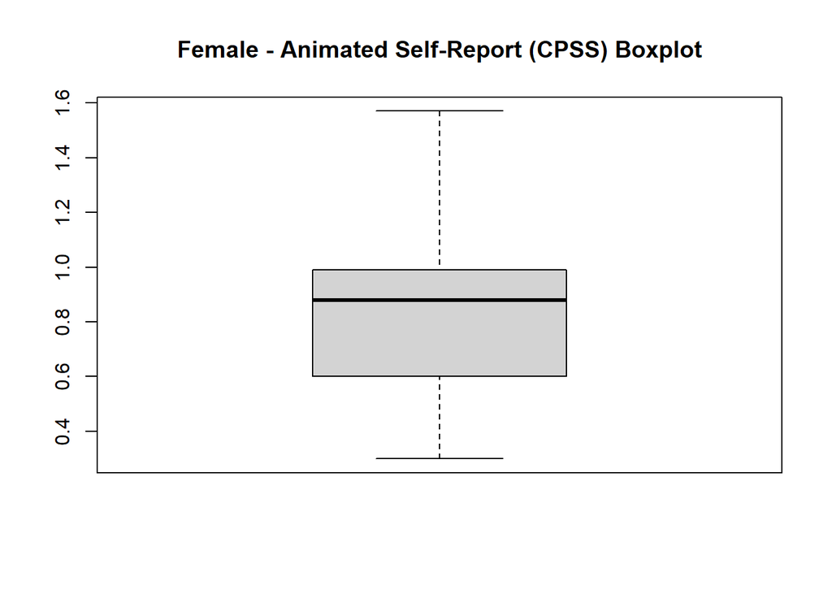

```r
boxplot(animated_female$cpss_diff,
        main="Female - Animated Self-Report (CPSS) Boxplot")
```

###### Animated Female - Observer-Rated (OR)

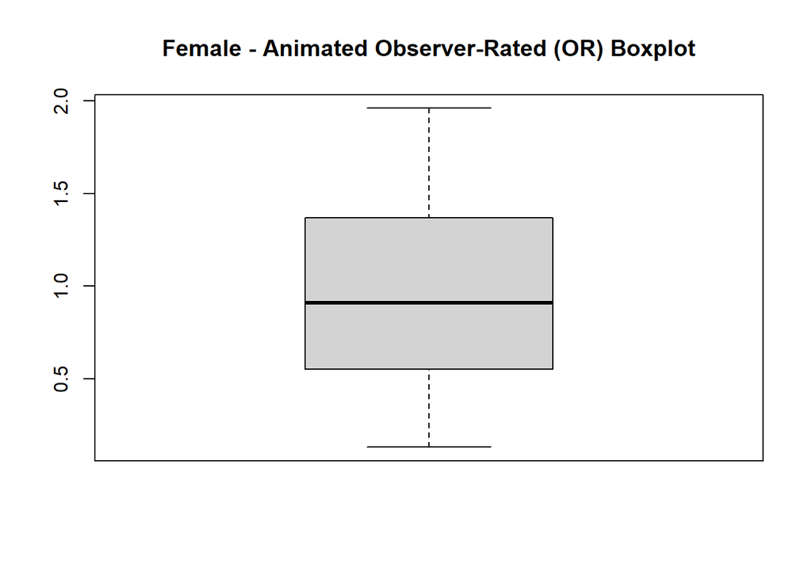

```r
boxplot(animated_female$or_diff,
        main="Female - Animated Observer-Rated (OR) Boxplot")
```

### 2. Central Tendancy

Mean, Median, Mode

#### 2.1 Mean

##### Control Mean Values

Mean Self-Report Difference

```r
mean_control_cpss <- mean(control_group$cpss_diff)
mean_control_cpss
```

```
## [1] 0.7865306
```

Mean Self-Report Difference - Male

```r
mean_control_cpss_male <- mean(control_male$cpss_diff)
mean_control_cpss_male
```

```
## [1] 0.815
```

Mean Self-Report Difference - Female

```r
mean_control_cpss_female <- mean(control_female$cpss_diff)
mean_control_cpss_female
```

```
## [1] 0.7592
```

```r
mean_control_or <- mean(control_male$or_diff)
mean_control_or
```

```
## [1] 0.9333333
```

```r
mean_control_or_male <- mean(control_female$or_diff)
mean_control_or_male
```

```
## [1] 0.874
```

```r
mean_control_or_female <- mean(control_group$or_diff)
mean_control_or_female
```

```
## [1] 0.9030612
```

##### Static Mean Values

Mean Self-Report Difference

```r
mean_static_cpss <- mean(static_group$cpss_diff)
mean_static_cpss
```

```
## [1] 0.664
```

Mean Self-Report Difference - Male

```r
mean_static_cpss_male <- mean(static_male$cpss_diff)
mean_static_cpss_male
```

```
## [1] 0.6664
```

Mean Self-Report Difference - Female

```r
mean_static_cpss_female <- mean(static_female$cpss_diff)
mean_static_cpss_female
```

```
## [1] 0.6616
```

```r
mean_static_or <- mean(static_male$or_diff)
mean_static_or
```

```
## [1] 0.7096
```

```r
mean_static_or_male <- mean(static_female$or_diff)
mean_static_or_male
```

```
## [1] 0.6752
```

```r
mean_static_or_female <- mean(static_group$or_diff)
mean_static_or_female
```

```
## [1] 0.6924
```

##### Animated Mean Values

Mean Self-Report Difference

```r
mean_animated_cpss <- mean(animated_group$cpss_diff)
mean_animated_cpss
```

```
## [1] 0.6934
```

Mean Self-Report Difference - Male

```r
mean_animated_cpss_male <- mean(animated_male$cpss_diff)
mean_animated_cpss_male
```

```
## [1] 0.5728
```

Mean Self-Report Difference - Female

```r
mean_animated_cpss_female <- mean(animated_female$cpss_diff)
mean_animated_cpss_female
```

```
## [1] 0.814
```

```r
mean_animated_or <- mean(animated_male$or_diff)
mean_animated_or
```

```
## [1] 0.6056
```

```r
mean_animated_or_male <- mean(animated_female$or_diff)
mean_animated_or_male
```

```
## [1] 0.9592
```

```r
mean_animated_or_female <- mean(animated_group$or_diff)
mean_animated_or_female
```

```
## [1] 0.7824
```

#### 2.2 Median

##### Control Median Values

Median Self-Report Difference

```r
median_control_cpss <- median(control_group$cpss_diff)
median_control_cpss
```

```
## [1] 0.73
```

Median Self-Report Difference - Male

```r
median_control_cpss_male <- median(control_male$cpss_diff)
median_control_cpss_male
```

```
## [1] 1.045
```

Median Self-Report Difference - Female

```r
median_control_cpss_female <- median(control_female$cpss_diff)
median_control_cpss_female
```

```
## [1] 0.66
```

```r
median_control_or <- median(control_male$or_diff)
median_control_or
```

```
## [1] 0.995
```

```r
median_control_or_male <- median(control_female$or_diff)
median_control_or_male
```

```
## [1] 0.78
```

```r
median_control_or_female <- median(control_group$or_diff)
median_control_or_female
```

```
## [1] 0.86
```

#### 2.3 Mode

Function used to calculate mode (tutorialspoint):

```r
getmode <- function(v) {
  uniqv <- unique(v)
  uniqv[which.max(tabulate(match(v, uniqv)))]
}
```

##### Control Mode Values

Mode Self-Report Difference

```r
mode_control_cpss <- getmode(control_group$cpss_diff)
mode_control_cpss
```

```
## [1] 1.22
```

Mode Self-Report Difference - Male

```r
mode_control_cpss_male <- getmode(control_male$cpss_diff)
mode_control_cpss_male
```

```
## [1] 1.22
```

Mode Self-Report Difference - Female

```r
mode_control_cpss_female <- getmode(control_female$cpss_diff)
mode_control_cpss_female
```

```
## [1] 0.66
```

```r
mode_control_or <- getmode(control_male$or_diff)
mode_control_or
```

```
## [1] 1.7
```

```r
mode_control_or_male <- getmode(control_female$or_diff)
mode_control_or_male
```

```
## [1] 0.78
```

```r
mode_control_or_female <- getmode(control_group$or_diff)
mode_control_or_female
```

```
## [1] 0.78
```

#### 3.1 Standard Deviation

##### Control Standard Deviation Values

Standard Deviation Self-Report Difference

```r
sd_control_cpss <- sd(control_group$cpss_diff)
sd_control_cpss
```

```
## [1] 1.01783
```

Standard Deviation Self-Report Difference - Male

```r
sd_control_cpss_male <- sd(control_male$cpss_diff)
sd_control_cpss_male
```

```
## [1] 1.420441
```

Standard Deviation Self-Report Difference - Female

```r
sd_control_cpss_female <- sd(control_female$cpss_diff)
sd_control_cpss_female
```

```
## [1] 0.3698414
```

```r
sd_control_or <- sd(control_male$or_diff)
sd_control_or
```

```
## [1] 1.481003
```

```r
sd_control_or_male <- sd(control_female$or_diff)
sd_control_or_male
```

```
## [1] 0.4315862
```

```r
sd_control_or_female <- sd(control_group$or_diff)
sd_control_or_female
```

```
## [1] 1.070057
```

##### Static Standard Deviation Values

Standard Deviation Self-Report Difference

```r
sd_static_cpss <- sd(static_group$cpss_diff)
sd_static_cpss
```

```
## [1] 1.015745
```

Standard Deviation Self-Report Difference - Male

```r
sd_static_cpss_male <- sd(static_male$cpss_diff)
sd_static_cpss_male
```

```
## [1] 1.416609
```

Standard Deviation Self-Report Difference - Female

```r
sd_static_cpss_female <- sd(static_female$cpss_diff)
sd_static_cpss_female
```

```
## [1] 0.3157093
```

```r
sd_static_or <- sd(static_male$or_diff)
sd_static_or
```

```
## [1] 1.647062
```

```r
sd_static_or_male <- sd(static_female$or_diff)
sd_static_or_male
```

```
## [1] 0.4128067
```

```r
sd_static_or_female <- sd(static_group$or_diff)
sd_static_or_female
```

```
## [1] 1.188483
```

##### Animated Standard Deviation Values

Standard Deviation Self-Report Difference

```r
sd_animated_cpss <- sd(animated_group$cpss_diff)
sd_animated_cpss
```

```
## [1] 0.9568157
```

Standard Deviation Self-Report Difference - Male

```r
sd_animated_cpss_male <- sd(animated_male$cpss_diff)
sd_animated_cpss_male
```

```
## [1] 1.31823
```

Standard Deviation Self-Report Difference - Female

```r
sd_animated_cpss_female <- sd(animated_female$cpss_diff)
sd_animated_cpss_female
```

```
## [1] 0.3179754
```

```r
sd_animated_or <- sd(animated_male$or_diff)
sd_animated_or
```

```
## [1] 1.29165
```

```r
sd_animated_or_male <- sd(animated_female$or_diff)
sd_animated_or_male
```

```
## [1] 0.4911459
```

```r
sd_animated_or_female <- sd(animated_group$or_diff)
sd_animated_or_female
```

```
## [1] 0.9834644
```

## Inferential Statistics

### T-test

```r
if(!require("tidyr")) install.packages("tidyr")
library(tidyr)

# 95% confidence level is default setting
data %>%
  select(gender, cpss_diff) %>%
  filter(gender %in% c("Male", "Female")) %>%
  drop_na(cpss_diff) %>%
  t.test(cpss_diff ~ gender, data = .)
```

```
##
##  Welch Two Sample t-test
##
## data:  cpss_diff by gender
## t = 0.37796, df = 81.685, p-value = 0.7064
## alternative hypothesis: true difference in means between group Female and group Male is not equal to 0
## 95 percent confidence interval:
##  -0.2641789  0.3880997
## sample estimates:
## mean in group Female   mean in group Male
##            0.7449333            0.6829730
```

```r
control_group %>%
  select(gender, cpss_diff) %>%
  filter(gender %in% c("Male", "Female")) %>%
  drop_na(cpss_diff) %>%
  t.test(cpss_diff ~ gender, data = .)
```

```
##
##  Welch Two Sample t-test
##
## data:  cpss_diff by gender
## t = -0.18648, df = 25.986, p-value = 0.8535
## alternative hypothesis: true difference in means between group Female and group Male is not equal to 0
## 95 percent confidence interval:
##  -0.6708979  0.5592979
## sample estimates:
## mean in group Female   mean in group Male
##               0.7592               0.8150
```

```r
static_group %>%
  select(gender, cpss_diff) %>%
  filter(gender %in% c("Male", "Female")) %>%
  drop_na(cpss_diff) %>%
  t.test(cpss_diff ~ gender, data = .)
```

```
##
##  Welch Two Sample t-test
##
## data:  cpss_diff by gender
## t = -0.016536, df = 26.378, p-value = 0.9869
## alternative hypothesis: true difference in means between group Female and group Male is not equal to 0
## 95 percent confidence interval:
##  -0.6010478  0.5914478
## sample estimates:
## mean in group Female   mean in group Male
##               0.6616               0.6664
```

```r
animated_group %>%
  select(gender, cpss_diff) %>%
  filter(gender %in% c("Male", "Female")) %>%
  drop_na(cpss_diff) %>%
  t.test(cpss_diff ~ gender, data = .)
```

```
##
##  Welch Two Sample t-test
##
## data:  cpss_diff by gender
## t = 0.88936, df = 26.783, p-value = 0.3817
## alternative hypothesis: true difference in means between group Female and group Male is not equal to 0
## 95 percent confidence interval:
##  -0.3154824  0.7978824
## sample estimates:
## mean in group Female   mean in group Male
##               0.8140               0.5728
```

```r
data %>%
  select(gender, or_diff) %>%
  filter(gender %in% c("Male", "Female")) %>%
  drop_na(or_diff) %>%
  t.test(or_diff ~ gender, data = .)
```

```
##
##  Welch Two Sample t-test
##
## data:  or_diff by gender
## t = 0.49942, df = 86.837, p-value = 0.6187
## alternative hypothesis: true difference in means between group Female and group Male is not equal to 0
## 95 percent confidence interval:
##  -0.2655308  0.4437434
## sample estimates:
## mean in group Female   mean in group Male
##            0.8361333            0.7470270
```

```r
control_group %>%
  select(gender, or_diff) %>%
  filter(gender %in% c("Male", "Female")) %>%
  drop_na(or_diff) %>%
  t.test(or_diff ~ gender, data = .)
```

```
##
##  Welch Two Sample t-test
##
## data:  or_diff by gender
## t = -0.18873, df = 26.733, p-value = 0.8517
## alternative hypothesis: true difference in means between group Female and group Male is not equal to 0
## 95 percent confidence interval:
##  -0.7047104  0.5860437
## sample estimates:
## mean in group Female   mean in group Male
##            0.8740000            0.9333333
```

```r
static_group %>%
  select(gender, or_diff) %>%
  filter(gender %in% c("Male", "Female")) %>%
  drop_na(or_diff) %>%
  t.test(or_diff ~ gender, data = .)
```

```
##
##  Welch Two Sample t-test
##
## data:  or_diff by gender
## t = -0.1013, df = 27.003, p-value = 0.9201
## alternative hypothesis: true difference in means between group Female and group Male is not equal to 0
## 95 percent confidence interval:
##  -0.7311997  0.6623997
## sample estimates:
## mean in group Female   mean in group Male
##               0.6752               0.7096
```

```r
animated_group %>%
  select(gender, or_diff) %>%
  filter(gender %in% c("Male", "Female")) %>%
  drop_na(or_diff) %>%
  t.test(or_diff ~ gender, data = .)
```

```
##
##  Welch Two Sample t-test
##
## data:  or_diff by gender
## t = 1.2794, df = 30.798, p-value = 0.2103
## alternative hypothesis: true difference in means between group Female and group Male is not equal to 0
## 95 percent confidence interval:
##  -0.2102211  0.9174211
## sample estimates:
## mean in group Female   mean in group Male
##               0.9592               0.6056
```

```r
data %>%
  select(gender, cpss_diff) %>%
  filter(gender %in% c("Male", "Female")) %>%
  drop_na(cpss_diff) %>%
  t.test(cpss_diff ~ gender, data = .)
```

```
##
##  Welch Two Sample t-test
##
## data:  cpss_diff by gender
## t = 0.37796, df = 81.685, p-value = 0.7064
## alternative hypothesis: true difference in means between group Female and group Male is not equal to 0
## 95 percent confidence interval:
##  -0.2641789  0.3880997
## sample estimates:
## mean in group Female   mean in group Male
##            0.7449333            0.6829730
```

# Discussion

# References

**OpenIntro Statistics:**

M., D., D., C. and Çetinkaya-Rundel, M., 2019. OpenIntro Statistics. OpenIntro, Incorporated.

OpenIntro Statistics. 2022. OpenIntro Statistics. [ONLINE] Available at: https://www.openintro.org/book/os/. [Accessed 21 December 2022].

**Tutorialspoint:**

R Tutorial. 2022. R Tutorial. [ONLINE] Available at: https://www.tutorialspoint.com/r/index.htm. [Accessed 21 December 2022].

**Table of Contents:**

Yihui Xie, J. J. Allaire, Garrett Grolemund. 2022. 3.1 HTML document | R Markdown: The Definitive Guide. [ONLINE] Available at: https://bookdown.org/yihui/rmarkdown/html-document.html. [Accessed 21 December 2022].

**Cleaning Data**

R Programming 101 (YouTube). 2022. Clean your data with R. R programming for beginners. - YouTube. [ONLINE] Available at: https://youtu.be/sV5lwAJ7vnQ. [Accessed 22 December 2022].

**T Test**

R Programming 101 (YouTube). 2022. Doing a t-test using R programming (in 4 minutes) - YouTube. [ONLINE] Available at: https://www.youtube.com/watch?v=x1RFWHV2VUU. [Accessed 23 December 2022].

**Markdown**

Markdown Basics. 2022. Markdown Basics. [ONLINE] Available at: https://rmarkdown.rstudio.com/authoring_basics.html. [Accessed 23 December 2022].

**PTSD and CBT research**

National Library of Medicine. 2022. Post‐traumatic stress disorder: a state‐of‐the‐art review of evidence and challenges. [ONLINE] Available at: https://www.ncbi.nlm.nih.gov/pmc/articles/PMC6732680/. [Accessed 23 December 2022].

Cognitive behavioural therapy (CBT) – PTSD UK. 2022. Cognitive behavioural therapy (CBT) – PTSD UK. [ONLINE] Available at: https://www.ptsduk.org/treatment-help/cognitive-behavioural-therapy-cbt/. [Accessed 23 December 2022].

**Statistical Analysis**

WallStreetMojo. 2022. Statistical Analysis. [ONLINE] Available at: https://www.wallstreetmojo.com/statistical-analysis/. [Accessed 23 December 2022].

**Histograms**

Data Camp. 2022. How to Make a Histogram with Basic R Tutorial. [ONLINE] Available at: https://www.datacamp.com/tutorial/make-histogram-basic-r. [Accessed 24 December 2022].